# 2D density graphs of cell populations

Manon Martin

July 18, 2025

# 1 Notes

## 1.1 Organize your analysis folder

1. create an Rproject in the folder of your analysis
2. the current analysis folder structure is:
- `main folder`:
  - `2D_densityPlot.Rmd`
  - your `.Rproj` file
- `data/Foxp2`:
  - Foxp2_e12_measures_pos***.txt
  - Foxp2_Hauteur_largeur.txt
- `results`: results from this analysis (`Foxp2-distances.xlsx`)
- `figures`: resulting figure from the analysis
3. open the `.Rproj` file
4. adapt the `2D_densityPlot.Rmd` file with your file names and condition (see below)
5. knit the file

## 1.2 How to compute the cartesian coordinates

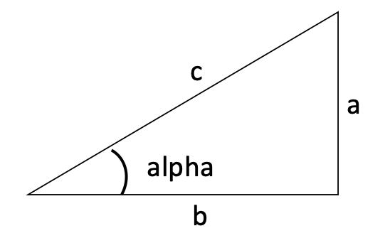

- $b = cos(\alpha)*c$
- $a = sin(\alpha)*c$

rem: $\alpha$ is in radian

- $\alpha$ -> `Angle` column in the data
- $c$ -> `Length` column in the data

# 2 Import the data

**`data_path` need to be adapted**

`data_path`: relative path (from where the `Rproj.` file is located) to the measures and Hauteur_largeur files

```r
data_path <- "data/Chx10_e14"
```

The data files need to be named as follows:

- **measures**: *treatment*_measures_pos*Position* where *treatment* and *Position* need to be adapted to your data (eg: “Foxp2_measures_posBrach.txt”)
- **Hauteur_largeur**: *treatment*_Hauteur_largeur.txt where *treatment* need to be adapted to your data (eg: “Foxp2_Hauteur_largeur.txt”) and should match the *treatment* name from measures files

```r
data_names <- grep("measures", list.files(data_path),
                   value = TRUE, ignore.case = TRUE) # measures

hl_name <- grep("Hauteur_largeur", list.files(data_path),
                value = TRUE, ignore.case = TRUE) # hauteur-largeur

trt <- sub("_measures.*","",data_names[1]) # name

es <- sub(".*_pos","",data_names)
es <- sub("\\.txt$","",es)


pander(paste0("positions: ",es))
```

*positions: Brach*, *positions: Lumb* and *positions: Thor*

```r
pander(paste0("data names: ",paste(data_names, collapse = ", ")))
```

data names: Chx10_e14_measures_posBrach.txt, Chx10_e14_measures_posLumb.txt, Chx10_e14_measures_posThor.txt

```r
pander(paste0("hauteur largeur name: ",hl_name))
```

hauteur largeur name: Chx10_e14_Hauteur_largeur.txt

```r
pander(paste0("treatment: ",trt))
```

treatment: Chx10_e14

```r
if (!dir.exists("results/")){
  dir.create("results/")
}
if (!dir.exists(paste0("figures/",trt,"/"))){
  dir.create(paste0("figures/",trt,"/"),recursive=TRUE)
}
```

We read the excel files and merge them ; then we compute distances (Polar –> cartesian coordinates (–> percentages)) with the `process_files` function.

```r
### read_excel_files and merge them
### compute distances (Polar --> cartesian coordinates (--> percentages))

# x=es[2]
# path = data_path

process_files <- function(path, data_names, hl_name,
                                x, trt = "condition") {
  # x: sheet name
  pos <- x

  ## Import the data =================================
  # dat ---------------------------
  dat <- readr::read_tsv(file.path(path, paste0(trt, "_measures_pos",pos,".txt")),
                         col_types = c( "d", "d", "c", "d", "f", "d"))

  cn =  c("Angle","Lenght",  "name", "cut_num", "cond", "Embryo")
  if(!identical(colnames(dat)[1:6],cn)){
    stop("colnames of measures file do not match: ", paste(cn, collapse=", "))
  }

  dat <- dat %>% rename("Length" = "Lenght")
  dat$position <- pos

  dat <- dat %>% select(Angle, Length, name, cut_num, cond, Embryo, position)
  dat <- dat %>% mutate(name = tolower(gsub(" ","",name)),
                      position = stringr::str_to_title(position),
                      cond =  as.factor(tolower(cond)))

  # dat

  # degree to radian
  dat$Angle <- (dat$Angle * pi) / (180)

  # LH ---------------------------
  LH <- readr::read_tsv(file.path(path, paste0(trt, "_Hauteur_largeur.txt")),
                        col_types = c("f", "d", "d", "c","f", "d"))

  cn =  c("type", "Angle", "Lenght", "name", "position", "cut_num")
  if(!identical(colnames(LH)[1:length(cn)],cn)){
    stop("colnames of Hauteur_largeur file do not match: ", paste(cn, collapse=", "))
  }

  LH <- LH %>% rename("Length" = "Lenght")
  LH$type <- as.factor(LH$type)
  LH$position <- as.factor(LH$position)
  LH <- LH %>% mutate(name = tolower(gsub(" ","",name)),
                      position = stringr::str_to_title(position))

  # degree to radian
  LH$Angle <- (LH$Angle * pi) / (180)



  # LH

  H_mat <- LH %>% filter(type == "Hauteur")
  L_mat <- LH %>% filter(type == "Largeur")

  ## Compute distances (Polar --> cartesian coordinates (--> percentages))  =================================

  ## Height (H) and Width (W) distances ---------------------------

  # - Height: looking for $a$
  # - Width: looking for $b$

  # H_mat <- H_mat %>%
  #   mutate(H = Length * sin(Angle))  %>% # dorsoventral DV H
  #   select(!c(type, Angle, Length))

  H_mat <- H_mat %>%
    mutate(H = Length) %>% # dorsoventral DV H
    select(!c(type, Angle, Length))

  # L_mat <- L_mat %>%
  #   mutate(W = Length * cos(Angle))  %>% # mediolateral ML W
  #   select(!c(type, Angle, Length))

  L_mat <- L_mat %>%
    mutate(W = Length) %>% # mediolateral ML W
    select(!c(type, Angle, Length))

  ## Dorsoventral (DV) and Mediolateral (ML) distances ---------------------------


  # $ML =  cos(\alpha)  c / W$
  # $DV =  sin(\alpha)  c / H$

  dat_unique <- dat %>%
    select(name, cut_num, position) %>%
    unique() %>%
    mutate(dat_mat = TRUE)

  H_mat_unique <- H_mat %>%
    filter(position == pos) %>%
    mutate(H_mat = TRUE)

  L_mat_unique <- L_mat %>%
    filter(position == pos) %>%
    mutate(L_mat = TRUE)

  df <- dat_unique %>%
    full_join(H_mat_unique, by = c("name", "position", "cut_num")) %>%
    full_join(L_mat_unique, by = c("name", "position", "cut_num"))

  # pander("missmatch between the two files?")
  # cat("\n")
  missmatch <- df %>% filter(is.na(dat_mat) | is.na(H_mat) | is.na(L_mat))
  # print(missmatch)
  # cat("\n")

  dat <- dat %>%
    left_join(H_mat, by = c("name", "position", "cut_num")) %>%
    left_join(L_mat, by = c("name", "position", "cut_num")) %>%
    mutate(
      ML = Length * cos(Angle) * 100 / W,
      DV = Length * sin(Angle) * 100 / H
    )

  # pander("summary of the data")
  # cat("\n")
  # print(summary(dat))

  return(list(
    data = dat, title = paste(trt, pos, sep = " - "),
    pos = pos, trt = trt, missmatch = missmatch
  ))
}
```

```r
res_list <- map(.x = es, .f = process_files,
                path=data_path, data_names=data_names,
                hl_name = hl_name,
                trt = trt)
names(res_list) <- es

pander("sheet names (positions)")
```

sheet names (positions)

```r
names(res_list)
```

```
## [1] "Brach" "Lumb"  "Thor"
```

```r
pander("Is there a missmatch between the two files? (eg condition is misspelled")
```

Is there a missmatch between the two files? (eg condition is misspelled

```r
missmatch = lapply(res_list, `[[`, "missmatch")
if (sum(sapply(missmatch, nrow))>0){
  warning("There is a missmatch between measures and Hauteur_largeur files",
          immediate. = TRUE)
  missmatch
}

pander("Overview of the final data files")
```

Overview of the final data files

```r
dat_list <- lapply(res_list, `[[`, "data")
dat_list
```

```
## $Brach
## # A tibble: 617 × 13
##      Angle Length name   cut_num cond  Embryo position ...7.x     H ...7.y     W
##      <dbl>  <dbl> <chr>    <dbl> <fct>  <dbl> <chr>    <lgl>  <dbl> <lgl>  <dbl>
##  1 1.57     1142. ntf3_…       1 ctrl       1 Brach    NA     1142. NA      455.
##  2 0.00440   455. ntf3_…       1 ctrl       1 Brach    NA     1142. NA      455.
##  3 0.233     164. ntf3_…       1 ctrl       1 Brach    NA     1142. NA      455.
##  4 0.0485    165. ntf3_…       1 ctrl       1 Brach    NA     1142. NA      455.
##  5 0.681     264. ntf3_…       1 ctrl       1 Brach    NA     1142. NA      455.
##  6 0.573     292. ntf3_…       1 ctrl       1 Brach    NA     1142. NA      455.
##  7 0.500     259. ntf3_…       1 ctrl       1 Brach    NA     1142. NA      455.
##  8 0.628     316. ntf3_…       1 ctrl       1 Brach    NA     1142. NA      455.
##  9 0.425     405. ntf3_…       1 ctrl       1 Brach    NA     1142. NA      455.
## 10 0.499     422. ntf3_…       1 ctrl       1 Brach    NA     1142. NA      455.
## # ℹ 607 more rows
## # ℹ 2 more variables: ML <dbl>, DV <dbl>
##
## $Lumb
## # A tibble: 836 × 13
##       Angle Length name  cut_num cond  Embryo position ...7.x     H ...7.y     W
##       <dbl>  <dbl> <chr>   <dbl> <fct>  <dbl> <chr>    <lgl>  <dbl> <lgl>  <dbl>
##  1  1.56      972. ntf3…       7 ctrl       1 Lumb     NA      972. NA      453.
##  2 -0.00442   453. ntf3…       7 ctrl       1 Lumb     NA      972. NA      453.
##  3  1.19      175. ntf3…       7 ctrl       1 Lumb     NA      972. NA      453.
##  4  0.974     196. ntf3…       7 ctrl       1 Lumb     NA      972. NA      453.
##  5  0.998     221. ntf3…       7 ctrl       1 Lumb     NA      972. NA      453.
##  6  1.12      222. ntf3…       7 ctrl       1 Lumb     NA      972. NA      453.
##  7  1.17      255. ntf3…       7 ctrl       1 Lumb     NA      972. NA      453.
##  8  1.03      255. ntf3…       7 ctrl       1 Lumb     NA      972. NA      453.
##  9  1.12      296. ntf3…       7 ctrl       1 Lumb     NA      972. NA      453.
## 10  1.11      321. ntf3…       7 ctrl       1 Lumb     NA      972. NA      453.
## # ℹ 826 more rows
## # ℹ 2 more variables: ML <dbl>, DV <dbl>
##
## $Thor
## # A tibble: 695 × 13
##     Angle Length name    cut_num cond  Embryo position ...7.x     H ...7.y     W
##     <dbl>  <dbl> <chr>     <dbl> <fct>  <dbl> <chr>    <lgl>  <dbl> <lgl>  <dbl>
##  1 1.57    1014  ntf3_c…       4 ctrl       1 Thor     NA      1014 NA      599.
##  2 0.0117   599. ntf3_c…       4 ctrl       1 Thor     NA      1014 NA      599.
##  3 1.17     155. ntf3_c…       4 ctrl       1 Thor     NA      1014 NA      599.
##  4 1.12     160. ntf3_c…       4 ctrl       1 Thor     NA      1014 NA      599.
##  5 1.02     179. ntf3_c…       4 ctrl       1 Thor     NA      1014 NA      599.
##  6 0.960    146. ntf3_c…       4 ctrl       1 Thor     NA      1014 NA      599.
##  7 1.05     205. ntf3_c…       4 ctrl       1 Thor     NA      1014 NA      599.
##  8 0.902    189. ntf3_c…       4 ctrl       1 Thor     NA      1014 NA      599.
##  9 0.751    187. ntf3_c…       4 ctrl       1 Thor     NA      1014 NA      599.
## 10 0.871    233. ntf3_c…       4 ctrl       1 Thor     NA      1014 NA      599.
## # ℹ 685 more rows
## # ℹ 2 more variables: ML <dbl>, DV <dbl>
```

```r
# write the results file
xlsx::write.xlsx(
  x = dat_list[[1]],
  file = paste0("results/", trt, "-distances.xlsx"),
  sheetName = names(dat_list)[1], append = FALSE
)

if (length(names(dat_list)) > 1) {
  for (i in names(dat_list)[-1]) {
    xlsx::write.xlsx(
      x = dat_list[[i]],
      file = paste0("results/", trt, "-distances.xlsx"),
      sheetName = i, append = TRUE
    )
  }
}
```

New columns of the final data files in `results/` folder (“*-distances.xlsx”):

- `H`: total height (H) distances
- `W`: total Width (W) distances
- `ML`: Medio-lateral position of interneuron
- `DV`: Dorso-ventral position of interneuron

# 3 Prepare a contour line made of splines from Bezier curves

```r
# plots a spline made of Bezier curves.

XYA <- tibble::tribble(
  ~x, ~y, ~angle,
  0, -10, -30,
  30, -15, 0,
  100, 0, 40,
  100, 40, 90,
  100, 85, 140,
  30, 100, 180,
  0, 97, 195,
)

get_bezier_points <- function(i, XYA) {
  # Compute Spline's Coordinates with get_bezier_points

  t <- seq(0, 1, length = 100)

  x <- XYA$x
  y <- XYA$y
  angles <- XYA$angle

  angles[angles < 0] <- 360 + angles[angles < 0]
  angles <- angles * pi / 180

  xb <- c(0, 0, 0, 0)
  yb <- c(0, 0, 0, 0)

  # Start/end points
  xb[1] <- x[i]
  xb[4] <- x[i + 1]
  yb[1] <- y[i]
  yb[4] <- y[i + 1]

  # Control points

  strength <- .375 # DEFAULT_STRENGTH

  rho <- pracma::hypot(x[i + 1] - x[i], y[i + 1] - y[i]) * strength

  res_pol2cart <- pracma::pol2cart(c(angles[i], rho))
  dx <- res_pol2cart[1]
  dy <- res_pol2cart[2]
  xb[2] <- xb[1] + dx
  yb[2] <- yb[1] + dy

  res_pol2cart <- pracma::pol2cart(c(angles[i + 1], rho))
  dx <- res_pol2cart[1]
  dy <- res_pol2cart[2]
  xb[3] <- xb[4] - dx
  yb[3] <- yb[4] - dy

  # Get Bezier curve's coordinates:
  bezier_points <- bezier(t = t, p = data.frame(xb, yb))
  bezier_points
}

bezier_points <- map((seq_len(nrow(XYA) - 1)), get_bezier_points, XYA = XYA)
bezier_points <- do.call(rbind, bezier_points)
colnames(bezier_points) <- c("x", "y")
bezier_points <- as.data.frame(bezier_points)
```

# 4 Plot 2D density

```r
# colors
col1 <- c("#518B8B", "#EE1289")
col2 <- c("#CCC9C9", "#000000")
col3 <- c("goldenrod2", "#0072B2")
col_list <- list(col1 = col1, col2 = col2, col3 = col3)

colChoice <- "col3"
cols <- col_list[[colChoice]]
```

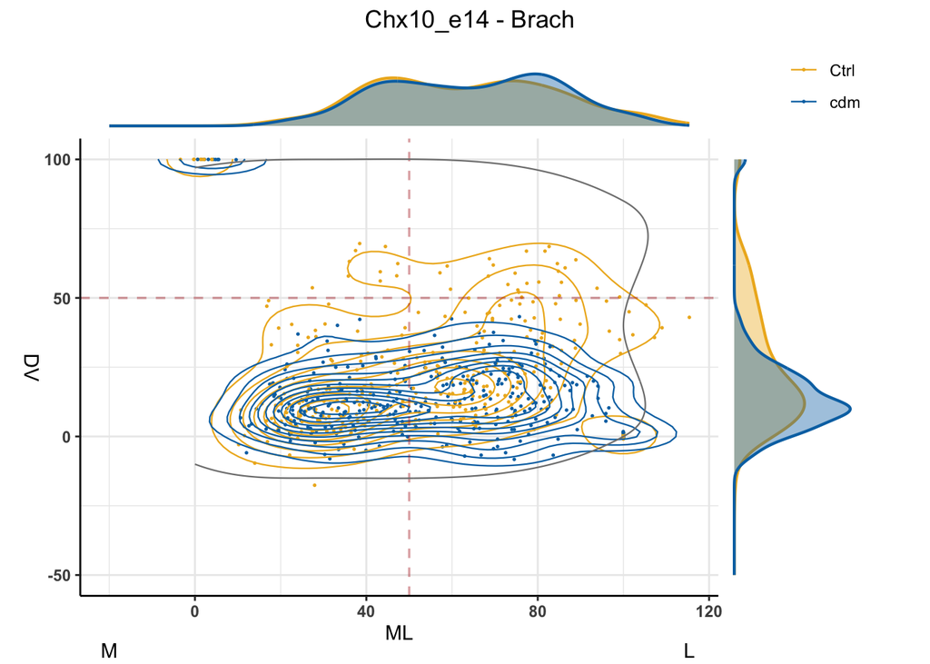

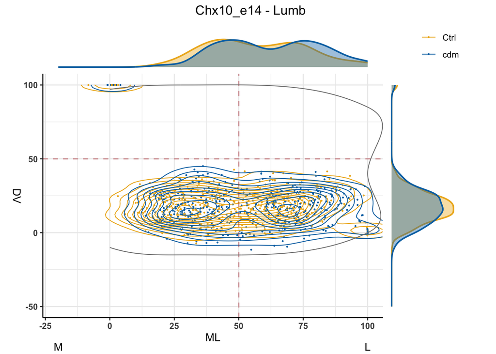

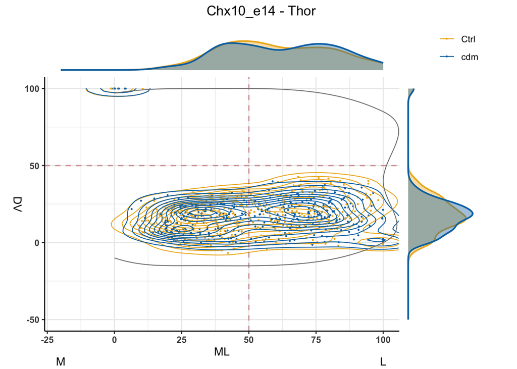

```r
# empty list of plots
p_list <- list()

# create the plots
for (i in seq_along(res_list)) {
  res <- res_list[[i]]

  res$data$cond <- relevel(res$data$cond, ref = "ctrl")
  res$data$cond <- plyr::revalue(res$data$cond, replace = c("ctrl" = "Ctrl"))
  table(res$data$cond)
  names(cols) <- levels(res$data$cond)

  dat <- res$data

  # filter the data
  dat <- dat[dat$ML >= -25, ]

  ## 2d density plot ------------------
  p <- dat %>% ggplot() +
    geom_point(aes(x = ML, y = DV, color = cond), size = 0.25) +
    geom_density_2d(aes(x = ML, y = DV, color = cond), linewidth = 0.4) +
    theme_bw() +
    geom_hline(
      yintercept = 50, linetype = "dashed",
      color = "firebrick", linewidth = 0.6, alpha = 0.4
    ) +
    geom_vline(
      xintercept = 50, linetype = "dashed",
      color = "firebrick", linewidth = 0.6, alpha = 0.4
    ) +
    labs(color = "Condition") +
    theme(axis.title.y = element_text(angle = -90)) +
    scale_color_manual(values = cols)

  # add the contour line
  p <- p + geom_path(
    data = bezier_points, mapping = aes(x = x, y = y),
    color = "gray50", linewidth = 0.4
  )

  p <- p +
    annotate("text", x = -64, y = max(100, res$data$DV), label = "D") +
    annotate("text", x = -64, y = -50, label = "V") +
    annotate("text", x = -20, y = -77, label = "M") +
    annotate("text", x = max(100, res$data$ML), y = -77, label = "L") +
    coord_cartesian(
      xlim = c(-20, max(100, res$data$ML)),
      ylim = c(-50, max(100, res$data$DV)), clip = "off"
    )

  leg <- get_legend(p + theme(legend.title = element_blank()))

  p <- p + theme(
    legend.position = "none",
    axis.text.x = element_text(face = "bold"),
    axis.text.y = element_text(face = "bold"),
    panel.border = element_blank(),
    axis.line = element_line(colour = "black")
  )


  # ML density ------------------
  dens1 <- dat %>% ggplot(aes(x = ML, fill = cond, color = cond)) +
    geom_density(alpha = 0.4, size = 0.75) +
    xlim(-50, max(100, dat$ML)) +
    theme_void() +
    theme(legend.position = "none") +
    scale_fill_manual(values = cols) +
    scale_color_manual(values = cols)

  # DV density ------------------
  dens2 <- dat %>% ggplot(aes(x = DV, fill = cond, color = cond)) +
    geom_density(alpha = 0.4, size = 0.75) +
    xlim(-50, max(100, dat$DV)) +
    theme_void() +
    theme(legend.position = "none") +
    coord_flip() +
    scale_fill_manual(values = cols) +
    scale_color_manual(values = cols)

  # plot layout with the patchwork package ------------------
  layout <- "##AA
  BBAA
  DDC#"

  pall <- as_ggplot(leg) + dens1 + dens2 + p +
    plot_layout(design = layout, widths = c(2.5, 2.5, 1, 0.5),
                heights = c(0.5, 1, 8)) +
    plot_annotation(res$title,
                    theme = theme(plot.title = element_text(hjust = 0.5)))
  pall

  p_list[[i]] <- pall

  # pdf
  ggsave(pall,
    filename =  paste0("figures/",trt,"/",gsub(" ", "", res$title), ".pdf"),
    width = 4.5, height = 6, scale = 0.6
  )

  # png
  ggsave(pall,
    filename = paste0("figures/",trt,"/",gsub(" ", "", res$title), ".png"),
    width = 4.5, height = 6, scale = 0.6, device = "png"
  )
}
p_list
```